# Data Hypothesis Testing

Reading in Sentiment Data

```r
library(arrow) #Library Needed to Read Parquet Files in R
library(dplyr)
library(effectsize)
library(ggplot2)
library(reshape2)
options(arrow.skip_nul = TRUE)
```

Reading in Data by Country

```r
df_america <- read_parquet('data/us_data_final.parquet')
head(df_america)
```

```
# A tibble: 6 × 16
     ID publishedAt    `source-name` location_code location category  year month
  <int> <chr>          <chr>         <chr>         <chr>    <chr>    <int> <int>
1   816 2020-08-07T11… Minneapolis … us            United … general   2020     8
2   901 2020-08-07T11… Google News   us            United … general   2020     8
3   961 2020-08-07T11… CNBC          us            United … general   2020     8
4  1054 2020-08-07T12… Google News   us            United … general   2020     8
5  1147 2020-08-07T12… CNET          us            United … general   2020     8
6  1335 2020-08-07T13… The Washingt… us            United … general   2020     8
# ℹ 8 more variables: new_title <chr>, neg <dbl>, neu <dbl>, pos <dbl>,
#   compound <dbl>, sentiment_category <chr>, bias_category <chr>,
#   bias_score <dbl>
```

```r
df_china <- read_parquet('data/china_data_final.parquet')
head(df_china)
```

```
# A tibble: 6 × 16
     ID publishedAt    `source-name` location_code location category  year month
  <int> <chr>          <chr>         <chr>         <chr>    <chr>    <int> <int>
1   246 2020-08-07T07… Sina.com.cn   cn            China    general   2020     8
2   384 2020-08-07T08… Sohu.com      cn            China    general   2020     8
3   421 2020-08-07T09… Sina.com.cn   cn            China    general   2020     8
4   437 2020-08-07T09… Chinanews.com cn            China    general   2020     8
5   621 2020-08-07T10… Sina.com.cn   cn            China    general   2020     8
6   631 2020-08-07T10… Reuters       cn            China    general   2020     8
# ℹ 8 more variables: new_title <chr>, neg <dbl>, neu <dbl>, pos <dbl>,
#   compound <dbl>, sentiment_category <chr>, bias_category <chr>,
#   bias_score <dbl>
```

```r
df_russia <- read_parquet('data/russia_data_final.parquet')
head(df_russia)
```

```
# A tibble: 6 × 16
     ID publishedAt    `source-name` location_code location category  year month
  <int> <chr>          <chr>         <chr>         <chr>    <chr>    <int> <int>
1   802 2020-08-07T11… Lenta         ru            Russian… general   2020     8
2   809 2020-08-07T11… Motor.ru      ru            Russian… general   2020     8
3   853 2020-08-07T11… Sportbox.ru   ru            Russian… general   2020     8
4   875 2020-08-07T11… Google News   ru            Russian… general   2020     8
5   918 2020-08-07T11… Gazeta.ru     ru            Russian… general   2020     8
6   968 2020-08-07T11… Vc.ru         ru            Russian… general   2020     8
# ℹ 8 more variables: new_title <chr>, neg <dbl>, neu <dbl>, pos <dbl>,
#   compound <dbl>, sentiment_category <chr>, bias_category <chr>,
#   bias_score <dbl>
```

```r
df_argentina <- read_parquet('data/argentina_data_final.parquet')
head(df_argentina)
```

```
# A tibble: 6 × 16
     ID publishedAt    `source-name` location_code location category  year month
  <int> <chr>          <chr>         <chr>         <chr>    <chr>    <int> <int>
1    78 2020-08-07T03… RPP           ar            Argenti… general   2020     8
2    80 2020-08-07T03… La Nacion     ar            Argenti… general   2020     8
3    82 2020-08-07T03… La Voz del I… ar            Argenti… general   2020     8
4   144 2020-08-07T06… Depor.com     ar            Argenti… general   2020     8
5   349 2020-08-07T08… Infobae       ar            Argenti… general   2020     8
6   535 2020-08-07T09… Infobae       ar            Argenti… general   2020     8
# ℹ 8 more variables: new_title <chr>, neg <dbl>, neu <dbl>, pos <dbl>,
#   compound <dbl>, sentiment_category <chr>, bias_category <chr>,
#   bias_score <dbl>
```

```r
df_india <- read_parquet('data/india_data_final.parquet')
head(df_india)
```

```
# A tibble: 6 × 16
     ID publishedAt    `source-name` location_code location category  year month
  <int> <chr>          <chr>         <chr>         <chr>    <chr>    <int> <int>
1   486 2020-08-07T09… The Indian E… in            India    general   2020     8
2   648 2020-08-07T10… Hindustan Ti… in            India    general   2020     8
3   693 2020-08-07T10… Zoom          in            India    general   2020     8
4   791 2020-08-07T11… Moneycontrol  in            India    general   2020     8
5   902 2020-08-07T11… NDTV News     in            India    general   2020     8
6   937 2020-08-07T11… Livemint      in            India    general   2020     8
# ℹ 8 more variables: new_title <chr>, neg <dbl>, neu <dbl>, pos <dbl>,
#   compound <dbl>, sentiment_category <chr>, bias_category <chr>,
#   bias_score <dbl>
```

```r
df_italy <- read_parquet('data/italy_data_final.parquet')
head(df_italy)
```

```
# A tibble: 6 × 16
     ID publishedAt    `source-name` location_code location category  year month
  <int> <chr>          <chr>         <chr>         <chr>    <chr>    <int> <int>
1   916 2020-08-07T11… Lanazione.it  it            Italy    general   2020     8
2  1064 2020-08-07T12… Trend-online… it            Italy    general   2020     8
3  1116 2020-08-07T12… Ilfattoquoti… it            Italy    general   2020     8
4  1252 2020-08-07T13… Ilmessaggero… it            Italy    general   2020     8
5  1362 2020-08-07T13… Liberoquotid… it            Italy    general   2020     8
6  1379 2020-08-07T13… Tg24.sky.it   it            Italy    general   2020     8
# ℹ 8 more variables: new_title <chr>, neg <dbl>, neu <dbl>, pos <dbl>,
#   compound <dbl>, sentiment_category <chr>, bias_category <chr>,
#   bias_score <dbl>
```

```r
df_canada <- read_parquet('data/canada_data_final.parquet')
head(df_canada)
```

```
# A tibble: 6 × 16
     ID publishedAt    `source-name` location_code location category  year month
  <int> <chr>          <chr>         <chr>         <chr>    <chr>    <int> <int>
1    44 2020-08-07T01… Variety       ca            Canada   general   2020     8
2   107 2020-08-07T04… Global Villa… ca            Canada   general   2020     8
3   206 2020-08-07T07… Sportsnet.ca  ca            Canada   general   2020     8
4   289 2020-08-07T08… Brandon Sun   ca            Canada   general   2020     8
5   606 2020-08-07T10… Net Newsledg… ca            Canada   general   2020     8
6   612 2020-08-07T10… TheChronicle… ca            Canada   general   2020     8
# ℹ 8 more variables: new_title <chr>, neg <dbl>, neu <dbl>, pos <dbl>,
#   compound <dbl>, sentiment_category <chr>, bias_category <chr>,
#   bias_score <dbl>
```

Within our data, Sentiment in news articles is split into 3 sections: negative sentiment, neutral sentiment, and positive sentiment, but also gives us a ‘compound sentiment score’ that grades the aritcle’s headline from a score of -1 to 1.

H0: The mean compound sentiment score for recorded articles in the United States before 2023 is 0 ($\mu_C =0$) Ha: The mean of the compound sentiment score for recorded articles in the United States before 2023 is not 0 ($\mu_C \neq 0$)

Applying Bootstrap Sampling to The T-Test

We took samples of N = 1000 articles repeated 1000 times for our 92,497 articles to use bootstrap sampling

```r
library(ggplot2)
set.seed(5100)
n <- 1000
Num_Samples <- 1000

US_Sentiment_Means <- numeric(Num_Samples)
for(i in 1:Num_Samples){
    bootstrap_samp <- sample(df_america$compound, size=n, replace=TRUE)
    US_Sentiment_Means[i] <- mean(bootstrap_samp)
}
cat("US Bootstrap Mean Compund Sentiment Score Summary")
```

```
US Bootstrap Mean Compund Sentiment Score Summary
```

```r
summary(US_Sentiment_Means)
```

```
     Min.   1st Qu.    Median      Mean   3rd Qu.      Max.
-0.029902  0.000768  0.008018  0.008440  0.016070  0.046042
```

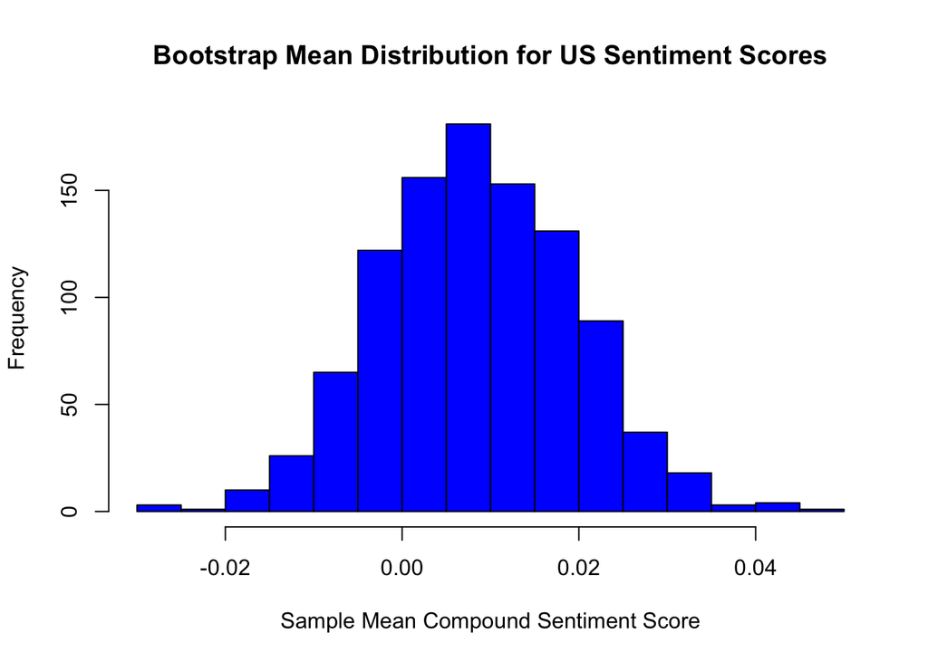

```r
#Histogram of Bootstrap Means
hist(US_Sentiment_Means, main = "Bootstrap Mean Distribution for US Sentiment Scores", xlab= "Sample Mean Compound Sentiment Score", col="blue", breaks=25)
```

```r
t.test(US_Sentiment_Means, mu = 0)
```

```
    One Sample t-test

data:  US_Sentiment_Means
t = 24.164, df = 999, p-value < 2.2e-16
alternative hypothesis: true mean is not equal to 0
95 percent confidence interval:
 0.007754252 0.009124981
sample estimates:
  mean of x
0.008439616
```

If we assume alpha = 0.05, the p-value being less than 2.2e-16 allows us to reject our null hypothesis and conclude that in the United States, the average compound sentiment score of news article headlines is not 0. Futhermore, because our t-test provided us with a 95% confidence interval due to our bootstrap sampling, we can also conclude that we are 95% confident that the true average compound sentiment score for news articles in the United States is between 0.007 and 0.009.

2 Sample T-Test: United States Compound Sentiment Scores vs Russia Compound Sentiment Scores

While our 95% confidence interval shows us that the true mean compound sentiment score of the US article headlines is between 0.007 and 0.009, we’re curious to see how that compares to another country’s headlines. For this 2-Sample T-Test, we’ll be comparing the mean compound sentiment scores of article headlines in the United States with the mean compound sentiment scores of Russia’s headlines using the same bootstrap sampling parameters as our previous example with the United States.

H0: The difference between mean compound sentiment scores for articles from Russia and articles from the United States is 0 Ha: The difference between mean compound sentiment scores for articles from Russia and articles from the United States is not 0

```r
set.seed(5100)
n <- 1000
Num_Samples <- 1000

Russian_Sentiment_Means <- numeric(Num_Samples)
for(i in 1:Num_Samples){
    bootstrap_samp <- sample(df_russia$compound, size=n, replace=TRUE)
    Russian_Sentiment_Means[i] <- mean(bootstrap_samp)
}
cat("Russian Bootstrap Mean Compund Sentiment Score Summary")
```

```
Russian Bootstrap Mean Compund Sentiment Score Summary
```

```r
summary(Russian_Sentiment_Means)
```

```
    Min.  1st Qu.   Median     Mean  3rd Qu.     Max.
-0.01431  0.01809  0.02500  0.02512  0.03231  0.06056
```

```r
t.test(Russian_Sentiment_Means, US_Sentiment_Means)
```

```
    Welch Two Sample t-test

data:  Russian_Sentiment_Means and US_Sentiment_Means
t = 33.217, df = 1995.9, p-value < 2.2e-16
alternative hypothesis: true difference in means is not equal to 0
95 percent confidence interval:
 0.01569524 0.01766482
sample estimates:
  mean of x   mean of y
0.025119650 0.008439616
```

Because our p-value is less than 2.2e-16, we can reject our null hypothesis at the 0.05 level and conclude that there is statistical evidence that the mean compound sentiment score of Russian article headlines is different than the mean compound sentiment score of United States article headlines. Furthermore, based on our 95% confidence interval, we can also conclude that the true difference in mean compound sentiment scores between Russian article headlines and US article headlines is between 0.015 and 0.017

ANOVA 1: Does Compund Sentiment Score Differ by Country?

While it is interesting that there is statistical evidence of a difference in mean compound sentiment scores between Russian article headlines and United States article headlines, We are curious to see if this applies to every country. Therefore, we decided to combine all of our data frames into one and ran an ANOVA test to see if this applies to every country.

H0: All countries in our data have equal mean compound sentiment scores Ha: At least one country has a different mean compound sentiment score

```r
df_all_countries <- rbind(df_america, df_china, df_russia, df_canada, df_india, df_italy, df_argentina)
counts <- as.data.frame(table(df_all_countries$location))
counts
```

```
                Var1   Freq
1          Argentina 119033
2             Canada 127445
3              China  91555
4              India 123754
5              Italy 129005
6 Russian Federation 113395
7      United States  92497
```

```r
anova_compound_country <- aov(compound ~location, data=df_all_countries)
summary(anova_compound_country)
```

```
                Df Sum Sq Mean Sq F value Pr(>F)
location         6   1245  207.54    1556 <2e-16 ***
Residuals   796677 106264    0.13
---
Signif. codes:  0 '***' 0.001 '**' 0.01 '*' 0.05 '.' 0.1 ' ' 1
```

```r
TukeyHSD(anova_compound_country)
```

```
  Tukey multiple comparisons of means
    95% family-wise confidence level

Fit: aov(formula = compound ~ location, data = df_all_countries)

$location
                                          diff          lwr          upr
Canada-Argentina                 -0.0003019876 -0.004642292  0.004038317
China-Argentina                   0.1207240233  0.115990677  0.125457369
India-Argentina                   0.0426671372  0.038295686  0.047038588
Italy-Argentina                   0.0124327115  0.008105099  0.016760324
Russian Federation-Argentina      0.0021111531 -0.002357121  0.006579427
United States-Argentina          -0.0144714814 -0.019191184 -0.009751779
China-Canada                      0.1210260109  0.116361074  0.125690948
India-Canada                      0.0429691248  0.038671840  0.047266409
Italy-Canada                      0.0127346991  0.008482018  0.016987381
Russian Federation-Canada         0.0024131407 -0.001982601  0.006808882
United States-Canada             -0.0141694938 -0.018820587 -0.009518401
India-China                      -0.0780568861 -0.082750816 -0.073362956
Italy-China                      -0.1082913118 -0.112944443 -0.103638181
Russian Federation-China         -0.1186128702 -0.123397101 -0.113828639
United States-China              -0.1351955046 -0.140215365 -0.130175645
Italy-India                      -0.0302344257 -0.034518891 -0.025949961
Russian Federation-India         -0.0405559841 -0.044982482 -0.036129486
United States-India              -0.0571386186 -0.061818790 -0.052458447
Russian Federation-Italy         -0.0103215584 -0.014704768 -0.005938349
United States-Italy              -0.0269041929 -0.031543444 -0.022264941
United States-Russian Federation -0.0165826345 -0.021353368 -0.011811901
                                     p adj
Canada-Argentina                 0.9999938
China-Argentina                  0.0000000
India-Argentina                  0.0000000
Italy-Argentina                  0.0000000
Russian Federation-Argentina     0.8058602
United States-Argentina          0.0000000
China-Canada                     0.0000000
India-Canada                     0.0000000
Italy-Canada                     0.0000000
Russian Federation-Canada        0.6703118
United States-Canada             0.0000000
India-China                      0.0000000
Italy-China                      0.0000000
Russian Federation-China         0.0000000
United States-China              0.0000000
Italy-India                      0.0000000
Russian Federation-India         0.0000000
United States-India              0.0000000
Russian Federation-Italy         0.0000000
United States-Italy              0.0000000
United States-Russian Federation 0.0000000
```

```r
eta_squared(anova_compound_country)
```

```
For one-way between subjects designs, partial eta squared is equivalent
  to eta squared. Returning eta squared.
```

```
# Effect Size for ANOVA

Parameter | Eta2 |       95% CI
-------------------------------
location  | 0.01 | [0.01, 1.00]

- One-sided CIs: upper bound fixed at [1.00].
```

```r
anova_bias_country <- aov(bias_score ~location, data=df_all_countries)
summary(anova_bias_country)
```

```
                Df Sum Sq Mean Sq F value Pr(>F)
location         6   4300   716.7    1290 <2e-16 ***
Residuals   796677 442534     0.6
---
Signif. codes:  0 '***' 0.001 '**' 0.01 '*' 0.05 '.' 0.1 ' ' 1
```

```r
TukeyHSD(anova_bias_country)
```

```
  Tukey multiple comparisons of means
    95% family-wise confidence level

Fit: aov(formula = bias_score ~ location, data = df_all_countries)

$location
                                          diff          lwr           upr
Canada-Argentina                  0.0049293484 -0.003927939  0.0137866355
China-Argentina                  -0.0103505476 -0.020009918 -0.0006911772
India-Argentina                   0.1874985208  0.178577673  0.1964193686
Italy-Argentina                   0.1157235395  0.106892153  0.1245549258
Russian Federation-Argentina      0.0041463535 -0.004972082  0.0132647886
United States-Argentina           0.1137484879  0.104116960  0.1233800161
China-Canada                     -0.0152798960 -0.024799664 -0.0057601282
India-Canada                      0.1825691724  0.173799676  0.1913386689
Italy-Canada                      0.1107941911  0.102115716  0.1194726660
Russian Federation-Canada        -0.0007829949 -0.009753413  0.0081874232
United States-Canada              0.1088191395  0.099327623  0.1183106557
India-China                       0.1978490684  0.188270135  0.2074280021
Italy-China                       0.1260740871  0.116578413  0.1355697613
Russian Federation-China          0.0144969011  0.004733689  0.0242601128
United States-China               0.1240990355  0.113854975  0.1343430962
Italy-India                      -0.0717749813 -0.080518317 -0.0630316456
Russian Federation-India         -0.1833521673 -0.192385350 -0.1743189844
United States-India              -0.0737500329 -0.083300890 -0.0641991758
Russian Federation-Italy         -0.1115771860 -0.120522031 -0.1026323411
United States-Italy              -0.0019750516 -0.011442402  0.0074922990
United States-Russian Federation  0.1096021344  0.099866468  0.1193378010
                                     p adj
Canada-Argentina                 0.6556462
China-Argentina                  0.0264772
India-Argentina                  0.0000000
Italy-Argentina                  0.0000000
Russian Federation-Argentina     0.8327740
United States-Argentina          0.0000000
China-Canada                     0.0000456
India-Canada                     0.0000000
Italy-Canada                     0.0000000
Russian Federation-Canada        0.9999762
United States-Canada             0.0000000
India-China                      0.0000000
Italy-China                      0.0000000
Russian Federation-China         0.0002419
United States-China              0.0000000
Italy-India                      0.0000000
Russian Federation-India         0.0000000
United States-India              0.0000000
Russian Federation-Italy         0.0000000
United States-Italy              0.9963661
United States-Russian Federation 0.0000000
```

```r
eta_squared(anova_bias_country)
```

```
For one-way between subjects designs, partial eta squared is equivalent
  to eta squared. Returning eta squared.
```

```
# Effect Size for ANOVA

Parameter |     Eta2 |       95% CI
-----------------------------------
location  | 9.62e-03 | [0.01, 1.00]

- One-sided CIs: upper bound fixed at [1.00].
```

ANOVA 3: Does An Article’s Country * Category Determine Its Compound Sentiment Score?

After proving that where an article is published affects its Mean Compound Sentiment Score, we became curious to see if the category/genre also affects an article’s compound sentiment score.

H0: All article categories * countries have equal mean sentiment Ha: At least one article category has a different mean compound sentiment score

```r
anova_compound_country_category <- aov(compound ~ category * location, data = df_all_countries)
summary(anova_compound_country_category)
```

```
                      Df Sum Sq Mean Sq F value Pr(>F)
category               6    695  115.84   881.3 <2e-16 ***
location               6   1191  198.53  1510.3 <2e-16 ***
category:location     36    906   25.18   191.6 <2e-16 ***
Residuals         796635 104716    0.13
---
Signif. codes:  0 '***' 0.001 '**' 0.01 '*' 0.05 '.' 0.1 ' ' 1
```

```r
p <- TukeyHSD(anova_compound_country_category)
table(df_all_countries$location, df_all_countries$category)
```

```
                     business entertainment general health science sports
  Argentina             15421         25357   10598  14049   14087  22603
  Canada                23272         23397   11500  20060    7435  23033
  China                 23982         23124    7674   1408    7744   9977
  India                 24910         24584   11212  18123    7168  21068
  Italy                 24209         25562   10671  13125   15109  20235
  Russian Federation    17347         25317   10248   1195   16361  23128
  United States         19089         19840    6194  17408    2895  21248

                     technology
  Argentina               16918
  Canada                  18748
  China                   17646
  India                   16689
  Italy                   20094
  Russian Federation      19799
  United States            5823
```

```r
eta_squared(anova_compound_country_category)
```

```
# Effect Size for ANOVA (Type I)

Parameter         | Eta2 (partial) |       95% CI
-------------------------------------------------
category          |       6.59e-03 | [0.01, 1.00]
location          |           0.01 | [0.01, 1.00]
category:location |       8.58e-03 | [0.01, 1.00]

- One-sided CIs: upper bound fixed at [1.00].
```

Significant US Health Articles: Health US: Health China Health US: General Italy Health US: General Russian Health US: Health Russian

```r
file_content <- readLines("data/Tukey_HSD_p_values.txt")
head(file_content, 50)
```

```
 [1] "entertainment:Argentina-business:Argentina                     0.0000000"
 [2] "general:Argentina-business:Argentina                           0.0000000"
 [3] "health:Argentina-business:Argentina                            0.1295323"
 [4] "science:Argentina-business:Argentina                           0.9998422"
 [5] "sports:Argentina-business:Argentina                            0.3613539"
 [6] "technology:Argentina-business:Argentina                        1.0000000"
 [7] "business:Canada-business:Argentina                             0.0000000"
 [8] "entertainment:Canada-business:Argentina                        0.0001139"
 [9] "general:Canada-business:Argentina                              0.0000000"
[10] "health:Canada-business:Argentina                               0.0000000"
[11] "science:Canada-business:Argentina                              1.0000000"
[12] "sports:Canada-business:Argentina                               0.0000003"
[13] "technology:Canada-business:Argentina                           1.0000000"
[14] "business:China-business:Argentina                              0.0000000"
[15] "entertainment:China-business:Argentina                         0.0000000"
```

[output cut: 35 more lines]

```r
lines <- readLines("data/Tukey_HSD_p_values.txt")
cat("Total lines in file:", length(lines), "\n")
```

```
Total lines in file: 1176
```

```r
comparisons <- character(length(lines))
p_values <- numeric(length(lines))

for(i in 1:length(lines)) {
  line <- trimws(lines[i])
  if(nchar(line) > 0) {
    parts <- strsplit(line, "\\s{2,}")[[1]]
    if(length(parts) >= 2) {
      comparisons[i] <- trimws(parts[1])
      p_values[i] <- as.numeric(trimws(parts[length(parts)]))
    } else {
      words <- strsplit(line, "\\s+")[[1]]
      if(length(words) >= 2) {
        comparisons[i] <- paste(words[1:(length(words)-1)], collapse = " ")
        p_values[i] <- as.numeric(words[length(words)])
      }
    }
  }
}

tukey_df <- data.frame(
  comparison = comparisons,
  p.adj = p_values,
  stringsAsFactors = FALSE
)

cat("Lines parsed:", length(lines), "\n")
```

```
Lines parsed: 1176
```

```r
cat("Valid comparisons:", sum(nchar(tukey_df$comparison) > 0), "\n")
```

```
Valid comparisons: 1176
```

```r
cat("Valid p-values:", sum(!is.na(tukey_df$p.adj)), "\n")
```

```
Valid p-values: 1176
```

```r
tukey_df <- tukey_df[!is.na(tukey_df$p.adj), ]
colnames(tukey_df)[1] <- "category:country-category:country"

str(tukey_df)
```

```
'data.frame':   1176 obs. of  2 variables:
 $ category:country-category:country: chr  "entertainment:Argentina-business:Argentina" "general:Argentina-business:Argentina" "health:Argentina-business:Argentina" "science:Argentina-business:Argentina" ...
 $ p.adj                            : num  0 0 0.13 1 0.361 ...
```

```r
head(tukey_df, 10)
```

```
            category:country-category:country     p.adj
1  entertainment:Argentina-business:Argentina 0.0000000
2        general:Argentina-business:Argentina 0.0000000
3         health:Argentina-business:Argentina 0.1295323
4        science:Argentina-business:Argentina 0.9998422
5         sports:Argentina-business:Argentina 0.3613539
6     technology:Argentina-business:Argentina 1.0000000
7          business:Canada-business:Argentina 0.0000000
8     entertainment:Canada-business:Argentina 0.0001139
9           general:Canada-business:Argentina 0.0000000
10           health:Canada-business:Argentina 0.0000000
```

```r
dim(tukey_df)
```

```
[1] 1176    2
```

```r
cat("Summary of adjusted p-values:\n")
```

```
Summary of adjusted p-values:
```

```r
summary(tukey_df$p.adj)
```

```
    Min.  1st Qu.   Median     Mean  3rd Qu.     Max.
0.00e+00 0.00e+00 0.00e+00 1.28e-01 1.30e-06 1.00e+00
```

```r
cat("\nNumber of significant comparisons (p < 0.05):", sum(tukey_df$p.adj < 0.05, na.rm = TRUE))
```

```
Number of significant comparisons (p < 0.05): 978
```

```r
cat("\nTotal number of comparisons:", nrow(tukey_df))
```

```
Total number of comparisons: 1176
```

```r
cat("\nProportion significant:", round(sum(tukey_df$p.adj < 0.05, na.rm = TRUE)/nrow(tukey_df), 3))
```

```
Proportion significant: 0.832
```

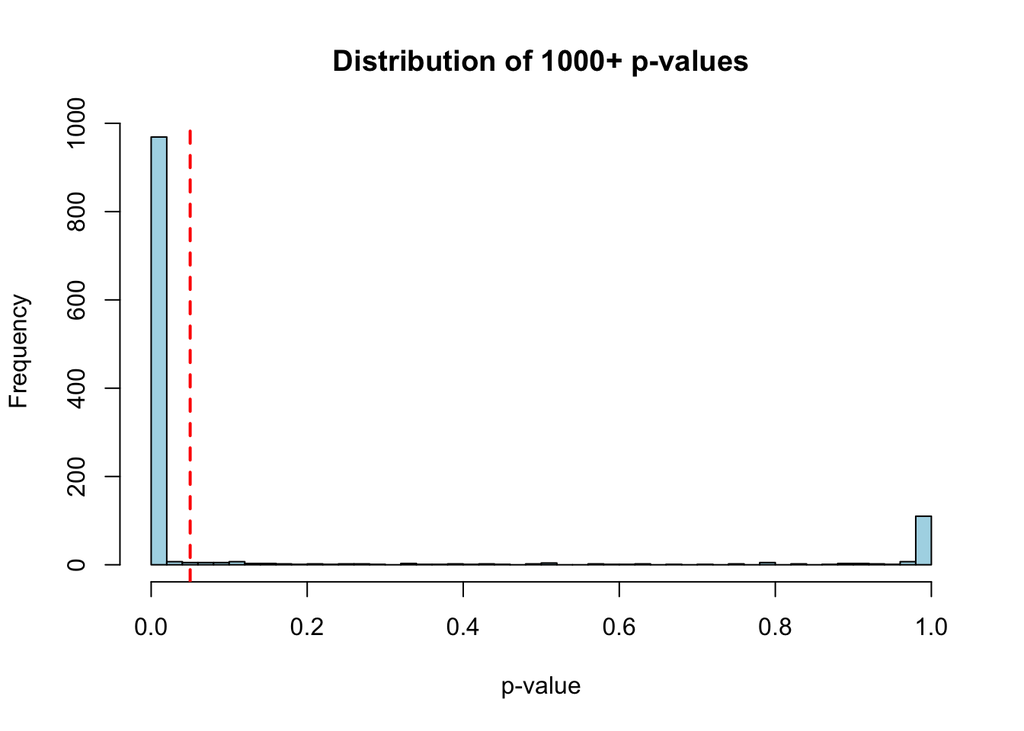

```r
hist(tukey_df$p.adj,
     main = "Distribution of 1000+ p-values",
     xlab = "p-value",
     breaks = 50,
     col = "lightblue")

abline(v = 0.05, col = "red", lwd = 2, lty = 2)
```

Conclusion: Reject Null Hypothesis, Article category significantly affects compound sentiment scores

Chi-Square Test of Independence: Comparing Sentiment Category to Bias Category

H0: Sentiment category and Bias category are independent Ha: Sentiment category and bias category are associated

```r
all_sentiment_bias <- table(df_all_countries$sentiment_category, df_all_countries$bias_category)
table(df_all_countries$sentiment_category)
```

```
negative  neutral positive
  198020   329671   268993
```

```r
table(df_all_countries$bias_category)
```

```
    Biased Non-biased
    382575     414109
```

```r
chi_sentiment_bias <- chisq.test(all_sentiment_bias)
chi_sentiment_bias
```

```
    Pearson's Chi-squared test

data:  all_sentiment_bias
X-squared = 2024.5, df = 2, p-value < 2.2e-16
```

```r
print(round(chi_sentiment_bias$expected))
```

```
           Biased Non-biased
  negative  95091     102929
  neutral  158311     171360
  positive 129173     139820
```

```r
print(round(chi_sentiment_bias$residuals))
```

```
           Biased Non-biased
  negative     -3          2
  neutral     -21         20
  positive     25        -24
```

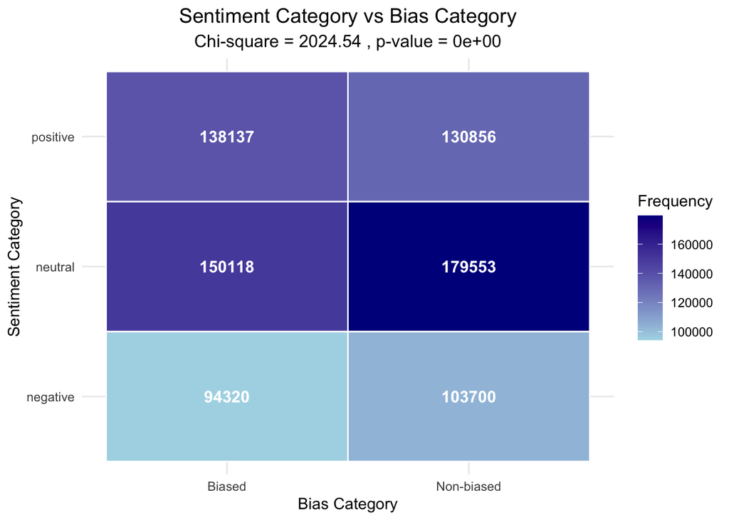

```r
all_sentiment_bias <- table(df_all_countries$sentiment_category, df_all_countries$bias_category)

sentiment_bias_df <- as.data.frame(all_sentiment_bias)
colnames(sentiment_bias_df) <- c("Sentiment", "Bias", "Frequency")

p1 <- ggplot(sentiment_bias_df, aes(x = Bias, y = Sentiment, fill = Frequency)) +
  geom_tile(color = "white", size = 0.5) +
  geom_text(aes(label = Frequency), color = "white", size = 4, fontface = "bold") +
  scale_fill_gradient(low = "lightblue", high = "darkblue") +
  labs(title = "Sentiment Category vs Bias Category",
       subtitle = paste("Chi-square =", round(chi_sentiment_bias$statistic, 2),
                       ", p-value =", format(chi_sentiment_bias$p.value, scientific = TRUE)),
       x = "Bias Category",
       y = "Sentiment Category") +
  theme_minimal() +
  theme(plot.title = element_text(hjust = 0.5, size = 14),
        plot.subtitle = element_text(hjust = 0.5, size = 12))
print(p1)
```

Conclusion: they are associated

Chi-Square Test 2: Genre X Sentiment Category

```r
counts <- t(as.data.frame(table(df_america$category)))
counts
```

```
     [,1]       [,2]            [,3]      [,4]     [,5]      [,6]
Var1 "business" "entertainment" "general" "health" "science" "sports"
Freq "19089"    "19840"         " 6194"   "17408"  " 2895"   "21248"
     [,7]
Var1 "technology"
Freq " 5823"
```

```r
all_sentiment_genre <- table(df_all_countries$category, df_all_countries$sentiment_category)


chi_sentiment_genre <- chisq.test(all_sentiment_genre)
chi_sentiment_genre
```

```
    Pearson's Chi-squared test

data:  all_sentiment_genre
X-squared = 10438, df = 12, p-value < 2.2e-16
```

```r
summary(chi_sentiment_genre)
```

```
          Length Class  Mode
statistic  1     -none- numeric
parameter  1     -none- numeric
p.value    1     -none- numeric
method     1     -none- character
data.name  1     -none- character
observed  21     table  numeric
expected  21     -none- numeric
residuals 21     table  numeric
stdres    21     table  numeric
```

Time Series

```r
library(lubridate)
library(Kendall)
df_all_countries$publishedAt <- as.Date(df_all_countries$publishedAt)
df_all_countries$year_month <- floor_date(df_all_countries$publishedAt, "month")

monthly_sent <- df_all_countries |> group_by(year_month) |> summarize(monthly_mean = mean(compound, na.rm=TRUE))

trend_model <- lm(monthly_mean ~ year_month, data=monthly_sent)
summary(trend_model)
```

```
Call:
lm(formula = monthly_mean ~ year_month, data = monthly_sent)

Residuals:
     Min       1Q   Median       3Q      Max
-0.35136 -0.10553  0.01256  0.05302  0.43871

Coefficients:
              Estimate Std. Error t value Pr(>|t|)
(Intercept)  9.351e-01  3.430e-01   2.727  0.00799 **
year_month  -4.857e-05  1.938e-05  -2.506  0.01442 *
---
Signif. codes:  0 '***' 0.001 '**' 0.01 '*' 0.05 '.' 0.1 ' ' 1

Residual standard error: 0.1451 on 74 degrees of freedom
  (1 observation deleted due to missingness)
Multiple R-squared:  0.07822,   Adjusted R-squared:  0.06576
F-statistic: 6.279 on 1 and 74 DF,  p-value: 0.01442
```

```r
MannKendall(monthly_sent$monthly_mean)
```

```
tau = -0.0244, 2-sided pvalue =0.7606
```

```r
monthly_sent$month <- factor(month(monthly_sent$year_month), labels = month.abb)

seasonal_anova <- aov(monthly_mean ~ month, data=monthly_sent)

summary(seasonal_anova)
```

```
            Df Sum Sq Mean Sq F value Pr(>F)
month       11 0.2584 0.02349   1.051  0.414
Residuals   64 1.4309 0.02236
1 observation deleted due to missingness
```

```r
TukeyHSD(seasonal_anova)
```

```
  Tukey multiple comparisons of means
    95% family-wise confidence level

Fit: aov(formula = monthly_mean ~ month, data = monthly_sent)

$month
                 diff        lwr       upr     p adj
Feb-Jan  0.1049557649 -0.1878437 0.3977553 0.9857366
Mar-Jan -0.0358216354 -0.3286211 0.2569779 0.9999995
Apr-Jan  0.1303651540 -0.1767255 0.4374558 0.9506824
May-Jan  0.0039857508 -0.2781629 0.2861344 1.0000000
Jun-Jan -0.0300331697 -0.3121818 0.2521155 0.9999999
Jul-Jan  0.0753050463 -0.2174944 0.3681045 0.9991778
Aug-Jan  0.0249403025 -0.2821504 0.3320310 1.0000000
Sep-Jan -0.0203612867 -0.3131608 0.2724382 1.0000000
Oct-Jan -0.0208372519 -0.3029859 0.2613114 1.0000000
Nov-Jan  0.0190527822 -0.2482354 0.2863409 1.0000000
Dec-Jan  0.1351291641 -0.1576703 0.4279287 0.9149961
Mar-Feb -0.1407774002 -0.4335769 0.1520221 0.8910216
Apr-Feb  0.0254093891 -0.2816813 0.3325001 1.0000000
May-Feb -0.1009700141 -0.3831187 0.1811786 0.9859210
Jun-Feb -0.1349889345 -0.4171376 0.1471597 0.8941647
Jul-Feb -0.0296507186 -0.3224502 0.2631488 0.9999999
Aug-Feb -0.0800154624 -0.3871062 0.2270752 0.9990730
Sep-Feb -0.1253170516 -0.4181165 0.1674824 0.9478772
Oct-Feb -0.1257930168 -0.4079417 0.1563556 0.9317228
Nov-Feb -0.0859029827 -0.3531911 0.1813852 0.9941136
Dec-Feb  0.0301733992 -0.2626261 0.3229729 0.9999999
Apr-Mar  0.1661867893 -0.1409039 0.4732775 0.7923890
May-Mar  0.0398073862 -0.2423413 0.3219560 0.9999979
Jun-Mar  0.0057884657 -0.2763602 0.2879371 1.0000000
Jul-Mar  0.1111266816 -0.1816728 0.4039262 0.9778940
Aug-Mar  0.0607619378 -0.2463288 0.3678526 0.9999338
Sep-Mar  0.0154603487 -0.2773391 0.3082598 1.0000000
Oct-Mar  0.0149843835 -0.2671643 0.2971330 1.0000000
Nov-Mar  0.0548744176 -0.2124137 0.3221626 0.9999047
Dec-Mar  0.1709507995 -0.1218487 0.4637503 0.7044562
May-Apr -0.1263794032 -0.4233323 0.1705735 0.9498309
Jun-Apr -0.1603983236 -0.4573512 0.1365546 0.7943258
Jul-Apr -0.0550601077 -0.3621508 0.2520306 0.9999754
```

[output cut: 18 more lines]

```
Aug-Jul -0.0503647438 -0.3574554 0.2567259 0.9999901
Sep-Jul -0.0956663329 -0.3884658 0.1971332 0.9932464
Oct-Jul -0.0961422981 -0.3782909 0.1860063 0.9904703
Nov-Jul -0.0562522641 -0.3235404 0.2110359 0.9998785
Dec-Jul  0.0598241178 -0.2329754 0.3526236 0.9999091
Sep-Aug -0.0453015891 -0.3523923 0.2617891 0.9999967
Oct-Aug -0.0457775543 -0.3427304 0.2511753 0.9999947
Nov-Aug -0.0058875203 -0.2887587 0.2769837 1.0000000
Dec-Aug  0.1101888616 -0.1969018 0.4172796 0.9856243
Oct-Sep -0.0004759652 -0.2826246 0.2816727 1.0000000
Nov-Sep  0.0394140689 -0.2278741 0.3067022 0.9999967
Dec-Sep  0.1554904508 -0.1373090 0.4482899 0.8112587
Nov-Oct  0.0398900341 -0.2156863 0.2954664 0.9999940
Dec-Oct  0.1559664160 -0.1261822 0.4381151 0.7697062
Dec-Nov  0.1160763819 -0.1512118 0.3833645 0.9425351
```

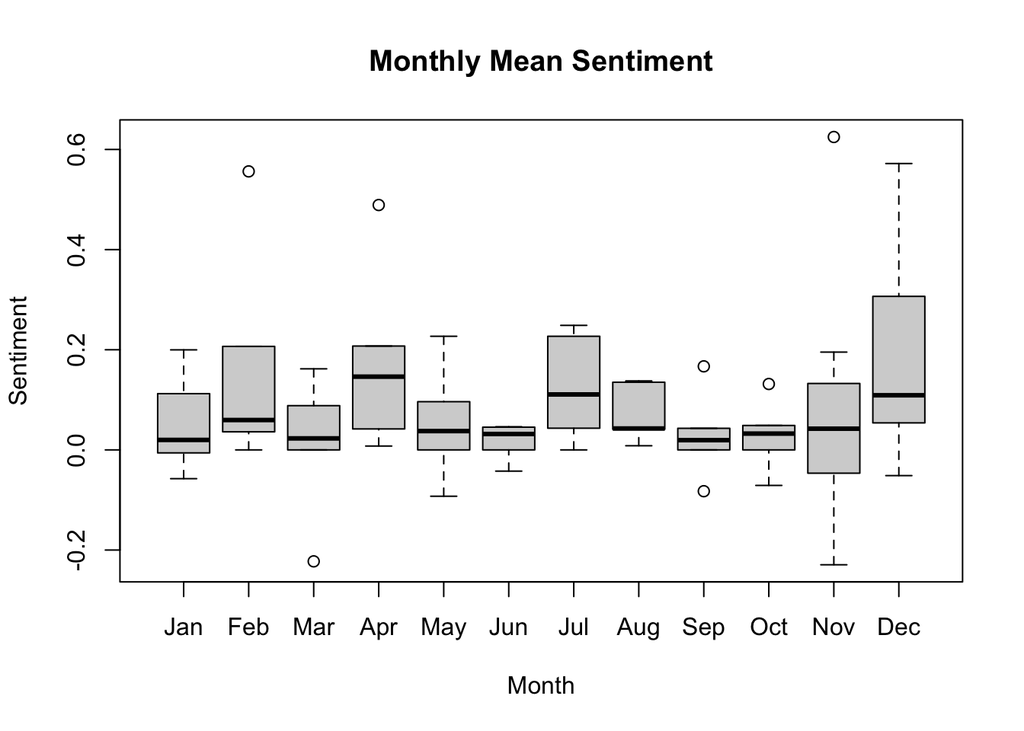

```r
plot(monthly_sent$month, monthly_sent$monthly_mean, main="Monthly Mean Sentiment", xlab="Month", ylab="Sentiment")
```

```r
monthly_country <- df_all_countries |> group_by(location, year_month) |> summarize(monthly_mean = mean(compound, na.rm=TRUE)) |> ungroup()
monthly_country$time_index <- as.numeric(monthly_country$year_month)

trend_country_model <- lm(monthly_mean ~ time_index * location, data=monthly_country)

summary(trend_country_model)
```

```
Call:
lm(formula = monthly_mean ~ time_index * location, data = monthly_country)

Residuals:
     Min       1Q   Median       3Q      Max
-0.66521 -0.05173 -0.01014  0.03810  0.63178

Coefficients:
                                        Estimate Std. Error t value Pr(>|t|)
(Intercept)                           -6.098e-01  1.187e+00  -0.514    0.608
time_index                             3.407e-05  6.450e-05   0.528    0.598
locationCanada                         1.775e+00  1.324e+00   1.341    0.181
locationChina                          2.238e+00  3.609e+00   0.620    0.536
locationIndia                          6.855e-01  1.402e+00   0.489    0.625
locationItaly                          7.210e-01  1.465e+00   0.492    0.623
locationRussian Federation             1.914e+00  1.284e+00   1.491    0.137
locationUnited States                  1.461e+00  1.371e+00   1.066    0.288
time_index:locationCanada             -9.595e-05  7.224e-05  -1.328    0.185
time_index:locationChina              -1.132e-04  1.940e-04  -0.583    0.560
time_index:locationIndia              -3.389e-05  7.657e-05  -0.443    0.658
time_index:locationItaly              -3.748e-05  7.991e-05  -0.469    0.639
time_index:locationRussian Federation -1.052e-04  6.998e-05  -1.503    0.134
time_index:locationUnited States      -7.798e-05  7.479e-05  -1.043    0.298

Residual standard error: 0.1675 on 251 degrees of freedom
  (1 observation deleted due to missingness)
Multiple R-squared:  0.08129,   Adjusted R-squared:  0.03371
F-statistic: 1.708 on 13 and 251 DF,  p-value: 0.05948
```

```r
monthly_bias <- df_all_countries |> group_by(year_month) |> summarize(monthly_mean = mean(bias_score, na.rm=TRUE))

trend_model <- lm(monthly_mean ~ year_month, data=monthly_bias)
summary(trend_model)
```

```
Call:
lm(formula = monthly_mean ~ year_month, data = monthly_bias)

Residuals:
     Min       1Q   Median       3Q      Max
-0.90800 -0.21391 -0.08672  0.22146  1.06733

Coefficients:
              Estimate Std. Error t value Pr(>|t|)
(Intercept) -1.905e+00  1.073e+00  -1.776   0.0799 .
year_month   1.134e-04  6.063e-05   1.870   0.0654 .
---
Signif. codes:  0 '***' 0.001 '**' 0.01 '*' 0.05 '.' 0.1 ' ' 1

Residual standard error: 0.4537 on 74 degrees of freedom
  (1 observation deleted due to missingness)
Multiple R-squared:  0.04513,   Adjusted R-squared:  0.03223
F-statistic: 3.498 on 1 and 74 DF,  p-value: 0.06541
```

```r
MannKendall(monthly_bias$monthly_mean)
```

```
tau = -0.0567, 2-sided pvalue =0.46801
```

```r
monthly_bias$month <- factor(month(monthly_bias$year_month), labels = month.abb)

seasonal_anova_bias <- aov(monthly_mean ~ month, data=monthly_bias)

summary(seasonal_anova_bias)
```

```
            Df Sum Sq Mean Sq F value Pr(>F)
month       11  2.818  0.2562   1.248  0.275
Residuals   64 13.135  0.2052
1 observation deleted due to missingness
```

```r
TukeyHSD(seasonal_anova_bias)
```

```
  Tukey multiple comparisons of means
    95% family-wise confidence level

Fit: aov(formula = monthly_mean ~ month, data = monthly_bias)

$month
                diff        lwr       upr     p adj
Feb-Jan  0.563905901 -0.3232256 1.4510374 0.5861265
Mar-Jan -0.201888892 -1.0890204 0.6852427 0.9997405
Apr-Jan  0.115009607 -0.8154218 1.0454410 0.9999995
May-Jan -0.150230294 -1.0050916 0.7046311 0.9999799
Jun-Jan  0.108065455 -0.7467959 0.9629268 0.9999993
Jul-Jan  0.027799894 -0.8593317 0.9149314 1.0000000
Aug-Jan  0.100969342 -0.8294621 1.0314008 0.9999999
Sep-Jan -0.181524654 -1.0686562 0.7056069 0.9999078
Oct-Jan  0.170830947 -0.6840304 1.0256923 0.9999270
Nov-Jan -0.041839478 -0.8516761 0.7679971 1.0000000
Dec-Jan  0.064095467 -0.8230361 0.9512270 1.0000000
Mar-Feb -0.765794793 -1.6529263 0.1213368 0.1559625
Apr-Feb -0.448896294 -1.3793277 0.4815351 0.8887794
May-Feb -0.714136195 -1.5689975 0.1407252 0.1911290
Jun-Feb -0.455840446 -1.3107018 0.3990209 0.8072557
Jul-Feb -0.536106006 -1.4232376 0.3510255 0.6586747
Aug-Feb -0.462936559 -1.3933680 0.4674949 0.8671544
Sep-Feb -0.745430554 -1.6325621 0.1417010 0.1845660
Oct-Feb -0.393074954 -1.2479363 0.4617864 0.9169247
Nov-Feb -0.605745379 -1.4155820 0.2040912 0.3369855
Dec-Feb -0.499810434 -1.3869420 0.3873211 0.7480959
Apr-Mar  0.316898499 -0.6135329 1.2473299 0.9905058
May-Mar  0.051658598 -0.8032028 0.9065199 1.0000000
Jun-Mar  0.309954347 -0.5449070 1.1648157 0.9844065
Jul-Mar  0.229688786 -0.6574428 1.1168203 0.9991256
Aug-Mar  0.302858234 -0.6275732 1.2332897 0.9934542
Sep-Mar  0.020364239 -0.8667673 0.9074958 1.0000000
Oct-Mar  0.372719839 -0.4821415 1.2275812 0.9410021
Nov-Mar  0.160049414 -0.6497872 0.9698860 0.9999346
Dec-Mar  0.265984359 -0.6211472 1.1531159 0.9967445
May-Apr -0.265239901 -1.1649555 0.6344757 0.9971899
Jun-Apr -0.006944152 -0.9066598 0.8927715 1.0000000
Jul-Apr -0.087209713 -1.0176411 0.8432217 1.0000000
```

[output cut: 18 more lines]

```
Aug-Jul  0.073169447 -0.8572620 1.0036009 1.0000000
Sep-Jul -0.209324548 -1.0964561 0.6778070 0.9996335
Oct-Jul  0.143031053 -0.7118303 0.9978924 0.9999878
Nov-Jul -0.069639372 -0.8794760 0.7401972 1.0000000
Dec-Jul  0.036295573 -0.8508360 0.9234271 1.0000000
Sep-Aug -0.282493995 -1.2129254 0.6479374 0.9963706
Oct-Aug  0.069861606 -0.8298540 0.9695772 1.0000000
Nov-Aug -0.142808820 -0.9998593 0.7142417 0.9999883
Dec-Aug -0.036873875 -0.9673053 0.8935575 1.0000000
Oct-Sep  0.352355601 -0.5025057 1.2072170 0.9597666
Nov-Sep  0.139685175 -0.6701514 0.9495218 0.9999834
Dec-Sep  0.245620121 -0.6415114 1.1327517 0.9983896
Nov-Oct -0.212670425 -0.9870223 0.5616815 0.9985025
Dec-Oct -0.106735480 -0.9615968 0.7481259 0.9999994
Dec-Nov  0.105934945 -0.7039017 0.9157715 0.9999991
```

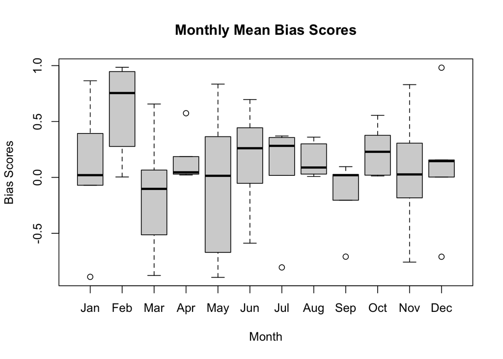

```r
plot(monthly_bias$month, monthly_bias$monthly_mean, main="Monthly Mean Bias Scores", xlab="Month", ylab="Bias Scores")
```

```r
monthly_country <- df_all_countries |> group_by(location, year_month) |> summarize(monthly_mean = mean(bias_score, na.rm=TRUE)) |> ungroup()
monthly_country$time_index <- as.numeric(monthly_country$year_month)

trend_country_model <- lm(monthly_mean ~ time_index * location, data=monthly_country)

summary(trend_country_model)
```

```
Call:
lm(formula = monthly_mean ~ time_index * location, data = monthly_country)

Residuals:
     Min       1Q   Median       3Q      Max
-1.23894 -0.16719 -0.02041  0.16536  1.18425

Coefficients:
                                        Estimate Std. Error t value Pr(>|t|)
(Intercept)                           -5.3212928  3.2744125  -1.625   0.1054
time_index                             0.0002866  0.0001779   1.611   0.1084
locationCanada                         7.5192826  3.6504451   2.060   0.0404 *
locationChina                          8.5822344  9.9550858   0.862   0.3895
locationIndia                          5.8314855  3.8675558   1.508   0.1329
locationItaly                          4.1400604  4.0398268   1.025   0.3064
locationRussian Federation             4.3397165  3.5400477   1.226   0.2214
locationUnited States                  6.2322722  3.7815518   1.648   0.1006
time_index:locationCanada             -0.0004016  0.0001992  -2.016   0.0449 *
time_index:locationChina              -0.0004637  0.0005350  -0.867   0.3869
time_index:locationIndia              -0.0002982  0.0002112  -1.412   0.1592
time_index:locationItaly              -0.0002240  0.0002204  -1.016   0.3104
time_index:locationRussian Federation -0.0002271  0.0001930  -1.176   0.2406
time_index:locationUnited States      -0.0003334  0.0002063  -1.616   0.1073
---
Signif. codes:  0 '***' 0.001 '**' 0.01 '*' 0.05 '.' 0.1 ' ' 1

Residual standard error: 0.4619 on 251 degrees of freedom
  (1 observation deleted due to missingness)
Multiple R-squared:  0.08675,   Adjusted R-squared:  0.03945
F-statistic: 1.834 on 13 and 251 DF,  p-value: 0.03853
```